# my title

my name (dummy@mail.com)

Last update: 03 March, 2024

# Clustering

## **Optional exercise**

Follow the tutorial from the [clustering section](https://genomicsclass.github.io/book/pages/clustering_and_heatmaps.html) of the book [PH525x series - Biomedical Data Science](http://genomicsclass.github.io/book/).

Install the package tissuesGeneExpression by running in R:

```r
# install.packages("devtools")
# install.packages("rafalib")
# install_github("genomicsclass/tissuesGeneExpression")
# library(devtools)
# library(rafalib)
# library(tissuesGeneExpression)
#
#
# data(tissuesGeneExpression)
# d <- dist( t(e) )
# mypar()
# hc <- hclust(d)
# hc
# table(t(e))
# tissue
# plot(hc,labels=tissue,cex=0.5)
# myplclust(hc, labels=tissue, lab.col=as.fumeric(tissue), cex=0.5)
# abline(h=120)
#
# hclusters <- cutree(hc, h=120)
# table(true=tissue, cluster=hclusters)
```

## Clustering gene expression data in healthy tissues

Download the [data](https://www.ebi.ac.uk/biostudies/arrayexpress/studies/E-MTAB-6081) (design and tpm files) corresponding to the publication [An RNASeq normal tissue atlas for mouse and rat](https://www.nature.com/articles/sdata2017185). Download the [gene expression data](https://storage.googleapis.com/adult-gtex/bulk-gex/v8/rna-seq/GTEx_Analysis_2017-06-05_v8_RNASeQCv1.1.9_gene_median_tpm.gct.gz) corresponding to the publication [The Genotype-Tissue Expression (GTEx) pilot analysis: multitissue gene regulation in humans](https://www.science.org/doi/10.1126/science.1262110) from the [GTEX portal](https://gtexportal.org/home/datasets)

From GTEX data, keep only tissues belonging to the following categories:

```r
# load data
human <- read.delim("data.gct", stringsAsFactors = FALSE, sep = "\t", skip = 2)
mouse <- read.delim("mouse_tpm.txt")
mouseD <- read.delim("mouse_design.txt")
rat <- read.delim("rat_tpm.txt")
ratD <- read.delim("rat_design.txt")

# convert cols to lower
colnames(human) <- tolower(colnames(human))
colnames(mouse) <- tolower(colnames(mouse))
colnames(rat) <- tolower(colnames(rat))


gtex_tissues <-  c("name", "colon", "ileum", "duodenum", "jejunum", "small intestine"  , "muscle", "pancreas", "liver", "stomach",  "kidney",  "quadriceps", "thymus", "heart" ,    "esophagus", "brain" )



# keep only the columns of interest

keep_subset <- function(tissues, columns){
  columns_to_keep_data <- c()

  for (t in tissues){
    for(a in columns){
      if (grepl(t, a)) {
        columns_to_keep_data <- c(columns_to_keep_data, a)
      }
    }
  }
  return (columns_to_keep_data)
}


human_cols <- keep_subset(gtex_tissues, colnames(human))

mouse_cols <- keep_subset(gtex_tissues, colnames(mouse))

rat_cols <- keep_subset(gtex_tissues, colnames(rat))


# Keep the columns of interest

human <- human[human_cols]

# For some reason... if we add a dummy columns and later take them out, the columns with the same name will have
# number suffixes

mouse <- mouse[mouse_cols]
new_column <- rep(0, nrow(mouse))
mouse <- cbind(dummy_column = new_column, mouse)


rat <- rat[rat_cols]
new_column <- rep(0, nrow(rat))
rat <- cbind(dummy_column = new_column, rat)

# Make the columns names unified... for example only brain... etc
unify_column_names <- function(df){
  new_column_names <- c()

  for (col in colnames(df)) {
    for (n in gtex_tissues){
      if (grepl(n, col)) {
        new_column_names <- c(new_column_names, n)
        break
      }
    }
  }
  return (new_column_names)
}

# put the unified column names in the dataframes
colnames(human) <- unify_column_names(human)
rownames(human) <- human$name
human <- human[,-1]


# here we have the use of dummy column... note the brain, brain.1, brain.2 etc in the output
colnames(mouse) <-c("dummy_column", unify_column_names(mouse))
mouse <- mouse[,-1]

colnames(rat) <- c("dummy_column", unify_column_names(rat))
rat <- rat[,-1]


# Keep only those columns in the datasets
cols_to_keep <- intersect(colnames(human), colnames(mouse))
cols_to_keep
```

```
##  [1] "colon"       "colon.1"     "ileum"       "pancreas"    "liver"
##  [6] "stomach"     "kidney"      "kidney.1"    "heart"       "heart.1"
## [11] "esophagus"   "esophagus.1" "esophagus.2" "brain"       "brain.1"
## [16] "brain.2"
```

```r
human <- human[,cols_to_keep]
mouse <- mouse[,cols_to_keep]

rat <- rat[,cols_to_keep]


# Add suffixes to differentiate columns by the species
colnames(human) <- paste(colnames(human), "_human", sep = "")

colnames(mouse) <- paste(colnames(mouse), "_mouse", sep = "")

colnames(rat) <- paste(colnames(rat), "_rat", sep = "")


# Load data to map human, rat and mouse genes
mapping <- read.csv("mapping.csv")
head(mapping)
```

```
##   Gene.stable.ID.version Rat.gene.stable.ID Mouse.gene.stable.ID
## 1      ENSG00000198888.2 ENSRNOG00000030644   ENSMUSG00000064341
## 2      ENSG00000198763.3 ENSRNOG00000031033   ENSMUSG00000064345
## 3      ENSG00000198804.2 ENSRNOG00000034234   ENSMUSG00000064351
## 4      ENSG00000198712.1 ENSRNOG00000030371   ENSMUSG00000064354
## 5      ENSG00000228253.1 ENSRNOG00000033299   ENSMUSG00000064356
## 6      ENSG00000198899.2 ENSRNOG00000031979   ENSMUSG00000064357
```

```r
# Add a new column ID
human$ID <- rownames(human)
rat$ID <- rownames(rat)
mouse$ID <- rownames(mouse)



# Create a one big dataframe with all the species
human_mapping <- merge(human, mapping, by.x = "ID", by.y = "Gene.stable.ID.version")

human_mapping_rat <- merge(human_mapping, rat, by.x = "Rat.gene.stable.ID", by.y = "ID")


human_mapping_rat_mouse <- merge(human_mapping_rat, mouse, by.x = "Mouse.gene.stable.ID", by.y = "ID")
```

**pro tip** Do not manually copy from the column names. Convert all column names from GTEX data to lower case, and split them appropriately.

Cluster tissues using gene expression data. Run k-means and hierarchical clustering. For each algorithm, determine the optimal number of clusters.

```r
#install.packages("factoextra")
library(factoextra)
```

```r
library(ggplot2)


# Hierarchical clustering
all_tables <- human_mapping_rat_mouse[-(1:2)]

all_tables_t <- t(all_tables)
all_tables_t <- as.data.frame(all_tables_t)

colnames(all_tables_t) <- all_tables_t[1,]
all_tables_t <- all_tables_t[-1,]


all_tables_t <- sapply(all_tables_t, as.numeric)


rownames(all_tables_t) <- colnames(all_tables[-1])

# Scale
all_tables_t_s <- scale(all_tables_t)

# Check for NaN or NA values in the dataframe
has_na <- any(is.na(all_tables_t_s))
has_na
```

```
## [1] TRUE
```

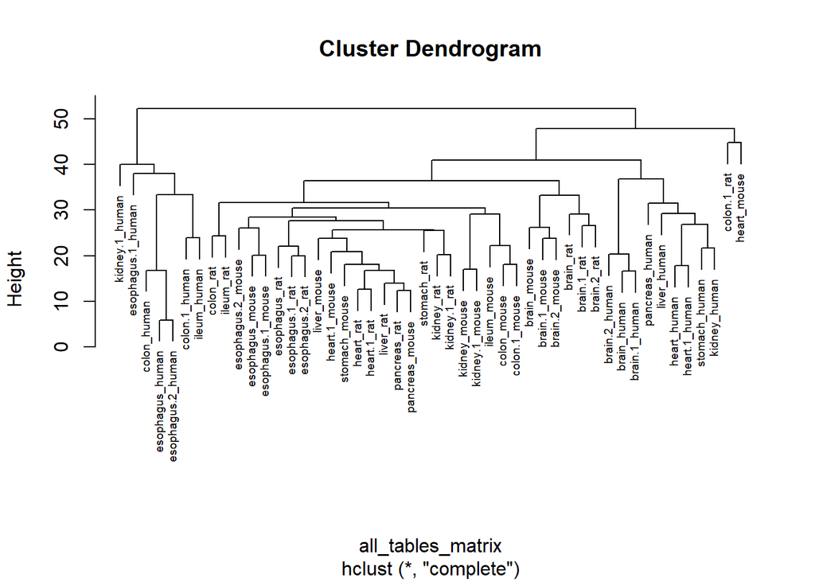

```r
# Remove NA
all_tables_t_s[is.na(all_tables_t_s)] <- 0
all_tables_matrix <- dist(all_tables_t_s, method = "euclidean")


# See the tree
hc_result <- hclust(all_tables_matrix, method = "complete" )
plot(hc_result, labels = rownames(all_tables_t), cex = 0.6)
```

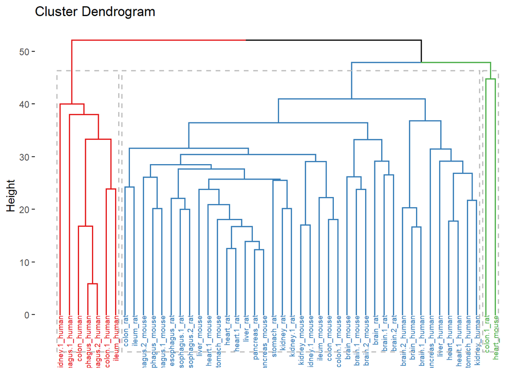

```r
# Color the tree into 3 groups
tree_coloured <- fviz_dend(hc_result, k = 3, k_colors = c("#E41A1C", "#377EB8", "#4DAF4A"),
          color_labels_by_k = TRUE, rect = TRUE, show_labels = TRUE, cex = 0.5) +
      guides(color = "none")
tree_coloured
```

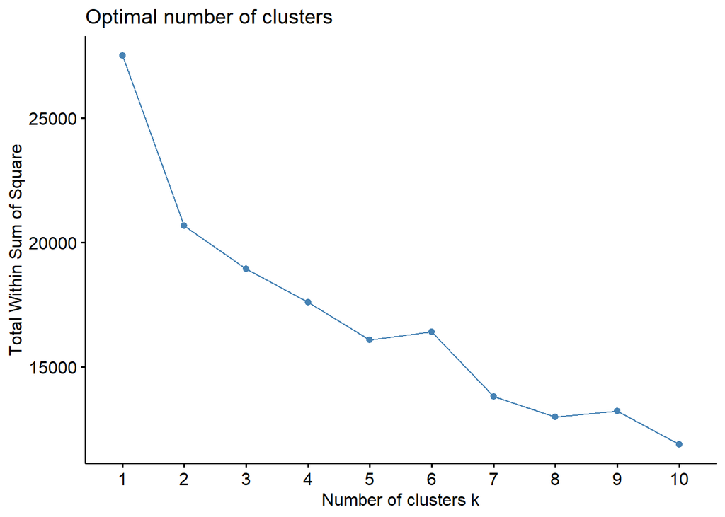

```r
# KMeans

fviz_nbclust(all_tables_t_s, kmeans, method = "wss")
```

```r
km <- kmeans(all_tables_t_s, centers = 3, iter.max=10, nstart = 25)
km$tot.withinss
```

```
## [1] 18687.83
```

```r
km$cluster
```

```
##       colon_human     colon.1_human       ileum_human    pancreas_human
##                 3                 3                 3                 1
##       liver_human     stomach_human      kidney_human    kidney.1_human
##                 1                 3                 1                 3
##       heart_human     heart.1_human   esophagus_human esophagus.1_human
##                 1                 1                 3                 3
## esophagus.2_human       brain_human     brain.1_human     brain.2_human
##                 3                 1                 1                 1
##         colon_rat       colon.1_rat         ileum_rat      pancreas_rat
##                 2                 2                 2                 2
##         liver_rat       stomach_rat        kidney_rat      kidney.1_rat
##                 2                 2                 2                 2
##         heart_rat       heart.1_rat     esophagus_rat   esophagus.1_rat
##                 2                 2                 2                 2
##   esophagus.2_rat         brain_rat       brain.1_rat       brain.2_rat
##                 2                 2                 2                 2
##       colon_mouse     colon.1_mouse       ileum_mouse    pancreas_mouse
##                 2                 2                 2                 2
##       liver_mouse     stomach_mouse      kidney_mouse    kidney.1_mouse
##                 2                 2                 2                 2
##       heart_mouse     heart.1_mouse   esophagus_mouse esophagus.1_mouse
##                 2                 2                 2                 2
## esophagus.2_mouse       brain_mouse     brain.1_mouse     brain.2_mouse
##                 2                 2                 2                 2
```

```r
table(km$cluster)
```

```
##
##  1  2  3
##  8 32  8
```

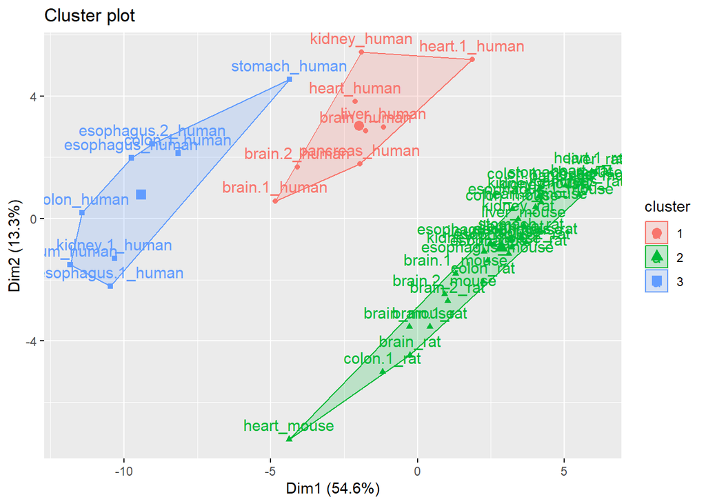

```r
res_cluster <- fviz_cluster(object = km, data = all_tables_matrix)
res_cluster
```

Compare the clustering results using both methodologies, and with the tissues/species. Show the results of the final partitions as a table.

```r
# Create a table to see in which cluster is which tissue
cluster_assignments <- cutree(hc_result, k = 3)

cluster_table <- data.frame(Dendrogram_cluster = cluster_assignments, Kmeans_cluster = km$cluster)
cluster_table <- cluster_table[order(cluster_table$Dendrogram_cluster), ]
cluster_table
```

```
##                   Dendrogram_cluster Kmeans_cluster
## colon_human                        1              3
## colon.1_human                      1              3
## ileum_human                        1              3
## kidney.1_human                     1              3
## esophagus_human                    1              3
## esophagus.1_human                  1              3
## esophagus.2_human                  1              3
## pancreas_human                     2              1
## liver_human                        2              1
## stomach_human                      2              3
## kidney_human                       2              1
## heart_human                        2              1
## heart.1_human                      2              1
## brain_human                        2              1
## brain.1_human                      2              1
## brain.2_human                      2              1
## colon_rat                          2              2
## ileum_rat                          2              2
## pancreas_rat                       2              2
## liver_rat                          2              2
## stomach_rat                        2              2
## kidney_rat                         2              2
## kidney.1_rat                       2              2
## heart_rat                          2              2
## heart.1_rat                        2              2
## esophagus_rat                      2              2
## esophagus.1_rat                    2              2
## esophagus.2_rat                    2              2
## brain_rat                          2              2
## brain.1_rat                        2              2
## brain.2_rat                        2              2
## colon_mouse                        2              2
## colon.1_mouse                      2              2
## ileum_mouse                        2              2
## pancreas_mouse                     2              2
## liver_mouse                        2              2
## stomach_mouse                      2              2
## kidney_mouse                       2              2
## kidney.1_mouse                     2              2
## heart.1_mouse                      2              2
## esophagus_mouse                    2              2
## esophagus.1_mouse                  2              2
## esophagus.2_mouse                  2              2
## brain_mouse                        2              2
## brain.1_mouse                      2              2
## brain.2_mouse                      2              2
## colon.1_rat                        3              2
## heart_mouse                        3              2
```

Plot a heatmap of the 50 genes with top variance over all samples. Add the information about tissue groups and model (human, rat and mouse) as annotations in the heatmap*.

```r
# Heatmap 50 genes with largest variance


v <- all_tables
rownames(v) <- v$ID
v <- v[,-1]

head(v)
```

```
##                    colon_human colon.1_human ileum_human pancreas_human
## ENSG00000007314.12   1.6301800     0.5890540    0.495800     0.15134100
## ENSG00000138802.11  29.0518000    20.5868000   21.177500     9.66371000
## ENSG00000198952.8   70.9746000    56.9548000   57.651800    20.67840000
## ENSG00000064195.7    0.1778230     0.2103720    0.201202     0.12247100
## ENSG00000123388.4    0.0150085     0.0414403    0.222818     0.00661148
## ENSG00000105281.12  25.0234000    50.5013000   43.162100    14.72280000
##                    liver_human stomach_human kidney_human kidney.1_human
## ENSG00000007314.12    0.126272     0.6295170     0.380994       1.427390
## ENSG00000138802.11   17.565500    16.3419000     9.915650      12.754500
## ENSG00000198952.8    36.363000    50.1288000    51.670400      61.880000
## ENSG00000064195.7     0.000000     0.0770018     0.138274       0.493274
## ENSG00000123388.4     0.000000     0.0000000     0.534858       1.519370
## ENSG00000105281.12    3.183990    44.4584000    25.821200      29.359800
##                    heart_human heart.1_human esophagus_human esophagus.1_human
## ENSG00000007314.12    0.706629     0.3686630       0.4165300         0.0985099
## ENSG00000138802.11   13.758000     8.9341600      28.1741000        24.8306000
## ENSG00000198952.8    43.908100    42.4361000      67.0832000        61.0783000
## ENSG00000064195.7     0.144137     0.0310664       0.1919740         3.7724200
## ENSG00000123388.4     0.000000     0.0000000       0.0116433         0.0119902
## ENSG00000105281.12   16.463200     5.5336300      37.4489000       106.3890000
##                    esophagus.2_human brain_human brain.1_human brain.2_human
## ENSG00000007314.12         0.3438510   0.0654451     0.0824729     0.1504940
## ENSG00000138802.11        28.4167000   6.5888700     7.6603900     8.2765500
## ENSG00000198952.8         71.0664000  31.8768000    40.7856000    37.3836000
## ENSG00000064195.7          0.1996030   0.0248963     0.0335715     0.0258017
## ENSG00000123388.4          0.0112296   0.0000000     0.0000000     0.0000000
## ENSG00000105281.12        38.9003000   1.6505500     0.9732780     1.8367000
##                     colon_rat colon.1_rat   ileum_rat pancreas_rat  liver_rat
## ENSG00000007314.12 0.01485687   0.1054050 0.009212757   0.00219416 0.01529979
## ENSG00000138802.11 2.42715963   3.0558555 2.174991496   0.04483718 0.65061256
## ENSG00000198952.8  4.77696667   6.2505892 4.660093776   0.32053813 1.02404634
## ENSG00000064195.7  0.06120383   0.1068294 0.008119718   0.00000000 0.00000000
## ENSG00000123388.4  0.00000000   0.0000000 0.000000000   0.00000000 0.00000000
## ENSG00000105281.12 4.02378819   6.0711158 2.438570048   0.11094817 0.09417543
##                    stomach_rat  kidney_rat kidney.1_rat  heart_rat heart.1_rat
## ENSG00000007314.12  0.01166621 0.024696866   0.01545026 0.04657222 0.022688895
## ENSG00000138802.11  1.19063211 1.171858993   1.44492122 1.12906538 1.056635167
## ENSG00000198952.8   2.68065184 2.526094844   3.68923248 2.69262054 2.336689214
## ENSG00000064195.7   0.66917947 0.002922706   0.00000000 0.00000000 0.004938171
```

[output cut: 29 more lines]

```
## ENSG00000105281.12  2.765124820     4.05606660 27.16780928      2.313364
##                    esophagus_mouse esophagus.1_mouse esophagus.2_mouse
## ENSG00000007314.12        2.782203          3.316902          1.374927
## ENSG00000138802.11        6.183372          7.583067          6.294538
## ENSG00000198952.8         6.551854          7.447541          5.556062
## ENSG00000064195.7         4.026998          3.683209          1.573082
## ENSG00000123388.4         0.000000          0.000000          0.000000
## ENSG00000105281.12       12.859705          7.333505         34.713881
##                    brain_mouse brain.1_mouse brain.2_mouse
## ENSG00000007314.12  0.00000000   0.001694239   0.004517517
## ENSG00000138802.11  9.36670218   6.859731007   6.820738122
## ENSG00000198952.8   8.50847750   8.149530828   7.660045320
## ENSG00000064195.7   0.02600681   0.008713228   0.011412676
## ENSG00000123388.4   0.00000000   0.000000000   0.000000000
## ENSG00000105281.12  0.65092041   0.679389773   0.473388280
```

```r
# Calculate variance for each row (gene ID)
variances <-as.data.frame(apply(v, 1, var))
row_names <- rownames(variances)

# Order the dataframe descendingly by values in the specified column and take the top 50 rows
top_50 <- rownames(head(variances[order(-variances$`apply(v, 1, var)`), , drop = FALSE ], 50))

# Take only the 50 gene Ids with the largest variance
heatmap_data <- v[top_50, ]

# Scale the data for a heatmap
heatmap_data <- scale(heatmap_data)

heatmap_data_matrix <- as.matrix(heatmap_data)

dim(heatmap_data_matrix)
```

```
## [1] 50 48
```

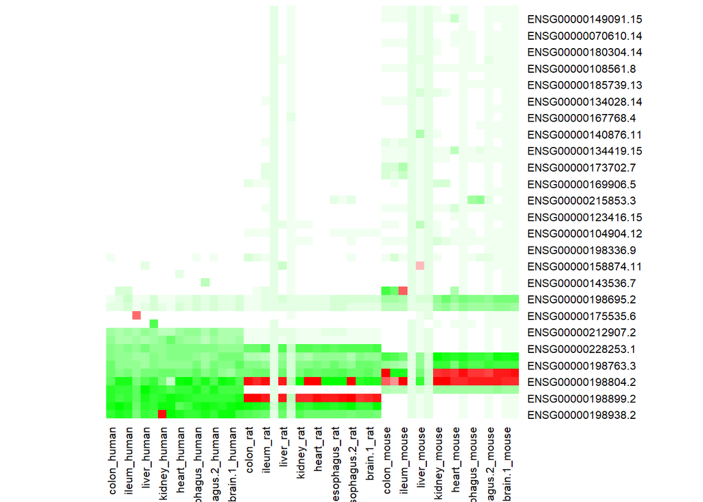

```r
red_shades <- rev(colorRampPalette(c("white", "red"))(20))
green_shades <- colorRampPalette(c("white", "green"))(20)
custom_palette <- c(green_shades, red_shades)

heatmap(as.matrix(heatmap_data), Rowv = NA, Colv = NA, scale = "none", col = custom_palette)
```

# Exercise 2: Dimensionality reduction

## PCA

With the gene expression for different tissues and models, perform a PCA on the data and visualize the results (PC1 and PC2, and also, PC3 ). Label the points in the plot with their respective tissues/models.

Visualize the data using the PC1 and PC2 again, but this time, color the observations by cluster, using the k means clusters, with k of your choice. Produce a caption for the plot

What are the top 50 genes that contribute to the PC1? Are they the same genes that are more variable according to the exercise 1?

## tSNE

Perform t-SNE on the dataset and visualize the results. Test at least 2 perplexity values.

# session info

R version 4.3.2 (2023-10-31 ucrt) Platform: x86_64-w64-mingw32/x64 (64-bit) Running under: Windows 11 x64 (build 22631)

Matrix products: default

locale: [1] LC_COLLATE=English_United States.utf8 [2] LC_CTYPE=English_United States.utf8  
[3] LC_MONETARY=English_United States.utf8 [4] LC_NUMERIC=C  
[5] LC_TIME=English_United States.utf8

time zone: Europe/Prague tzcode source: internal

attached base packages: [1] stats graphics grDevices utils datasets methods base

other attached packages: [1] factoextra_1.0.7 ggplot2_3.4.4

loaded via a namespace (and not attached): [1] viridis_0.6.4 sass_0.4.7 utf8_1.2.4 generics_0.1.3  
[5] tidyr_1.3.0 rstatix_0.7.2 digest_0.6.33 magrittr_2.0.3  
[9] evaluate_0.23 grid_4.3.2 fastmap_1.1.1 jsonlite_1.8.7  
[13] ggrepel_0.9.4 backports_1.4.1 gridExtra_2.3 purrr_1.0.2  
[17] fansi_1.0.5 viridisLite_0.4.2 scales_1.2.1 jquerylib_0.1.4  
[21] abind_1.4-5 cli_3.6.1 crayon_1.5.2 rlang_1.1.2  
[25] munsell_0.5.0 withr_2.5.2 cachem_1.0.8 yaml_2.3.7  
[29] tools_4.3.2 ggsignif_0.6.4 dplyr_1.1.4 colorspace_2.1-0 [33] ggpubr_0.6.0 broom_1.0.5 vctrs_0.6.4 R6_2.5.1  
[37] lifecycle_1.0.4 car_3.1-2 pkgconfig_2.0.3 dendextend_1.17.1 [41] pillar_1.9.0 bslib_0.6.0 gtable_0.3.4 glue_1.6.2  
[45] Rcpp_1.0.11 highr_0.10 xfun_0.41 tibble_3.2.1  
[49] tidyselect_1.2.0 rstudioapi_0.15.0 knitr_1.45 farver_2.1.1  
[53] htmltools_0.5.7 rmarkdown_2.25 carData_3.0-5 labeling_0.4.3  
[57] compiler_4.3.2